# (PSL) GBM for Regression

### Preliminaries

Before running a GBM model, decide on the following hyperparameters:

- loss Function: For regression tasks, ‘Gaussian’ (squared error) is commonly used
- `n.trees`: number of trees (default = 100)
- `shrinkage`: shrinkage factor or learning rate (default = 0.1)
- `bag.fraction`: fraction of the training data used for learning (default = 0.5)
- `cv.folds`: number of folds for cross-validation (default = 0, i.e., no CV error returned)
- `interaction.depth`: depth of individual trees (default 1)

### Case Study: Housing Data

We first split the Boston Housing dataset into a 70% training set and a 30% test set.

```r
library(gbm)
url = "https://liangfgithub.github.io/Data/HousingData.csv"
mydata = read.csv(url)
n = nrow(mydata)
ntest = round(n * 0.3)
set.seed(1234)
test.id = sample(1:n, ntest)
```

### Fit a GBM

```r
myfit1 = gbm(Y ~ . , data = mydata[-test.id, ],
            distribution = "gaussian",
            n.trees = 100,
            shrinkage = 1,
            interaction.depth = 3,
            bag.fraction = 1,
            cv.folds = 5)
myfit1;
```

[output not shown]

### Optimal Stopping Point

```r
opt.size = gbm.perf(myfit1)
```

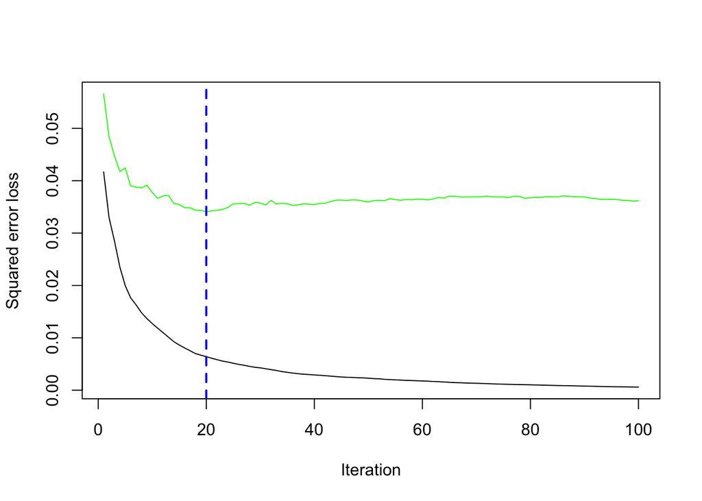

### Performance Evaluation

We evaluate the model’s performance on the test data against the number of trees. It turns out that the performance of the forest with the optimal `opt.size` is reasonably good even if it’s not the smallest test error.

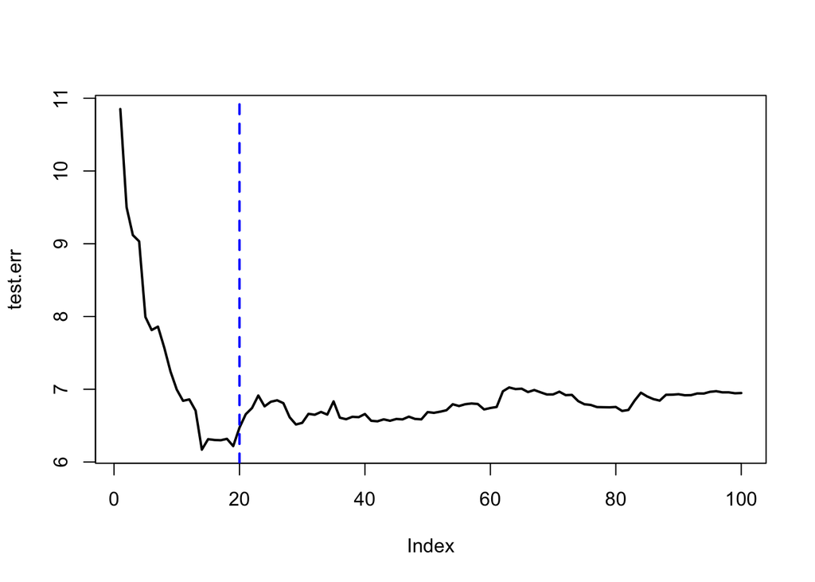

```r
size = 1:myfit1$n.trees
test.err = rep(0, length(size))
for(i in 1:length(size)){
    y.pred = predict(myfit1, mydata[test.id, ], n.trees = size[i])
    test.err[i] = sum((mydata$Y[test.id] - y.pred)^2)
}
plot(test.err, type = "n")
lines(size, test.err, lwd = 2)
abline(v = opt.size, lwd = 2, lty = 2, col = "blue")
```

### Fit Another GBM

We then construct another GBM model but with shrinkage. Because of this, we will need more trees and also set the subsampling rate to 50%. In this scenario, the optimal stopping point was over 200 trees.

```r
myfit2 = gbm(Y ~ . , data = mydata[-test.id, ],
            distribution = "gaussian",
            n.trees = 1000,
            shrinkage = 0.1,
            interaction.depth = 3,
            bag.fraction = 0.5,
            cv.folds = 5)
opt.size = gbm.perf(myfit2)
```

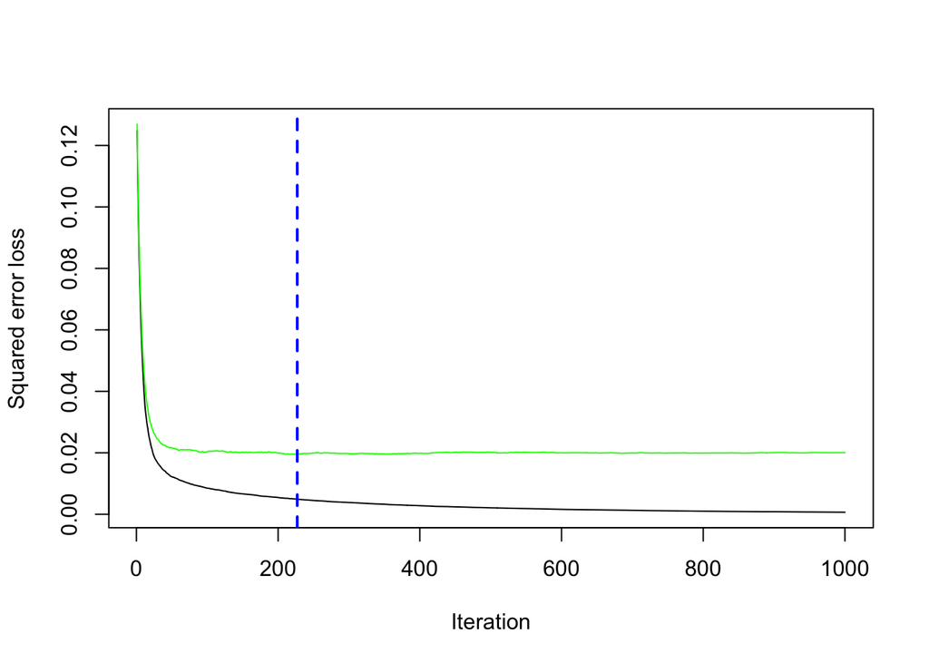

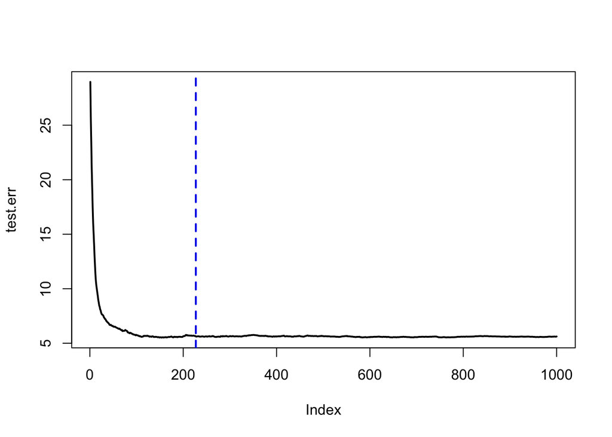

```r
size = 1:myfit2$n.trees
test.err = rep(0, length(size))
for(i in 1:length(size)){
    y.pred = predict(myfit2, mydata[test.id, ], n.trees = size[i])
    test.err[i] = sum((mydata$Y[test.id] - y.pred)^2)
}
plot(test.err, type = "n")
lines(size, test.err, lwd = 2)
abline(v = opt.size, lwd = 2, lty = 2, col = "blue")
```

### Variable Importance

GBM in R provides measures for variable importance similar to Random Forest. You can access these measures using the `summary()` function.

```r
par(mfrow=c(1, 2))
summary(myfit1, cBars = 10,
  method = relative.influence,
  las = 2)
```

```
##             var     rel.inf
## lstat     lstat 55.48719511
## rm           rm 23.49623645
## crim       crim  9.92391857
## lon         lon  2.61359901
## dis         dis  1.97426669
## nox         nox  1.67166826
## lat         lat  1.57319028
## age         age  1.08397273
## ptratio ptratio  0.97920710
## tax         tax  0.57316429
## chas       chas  0.28845125
## zn           zn  0.14235518
## rad         rad  0.12114019
## indus     indus  0.07163489
```

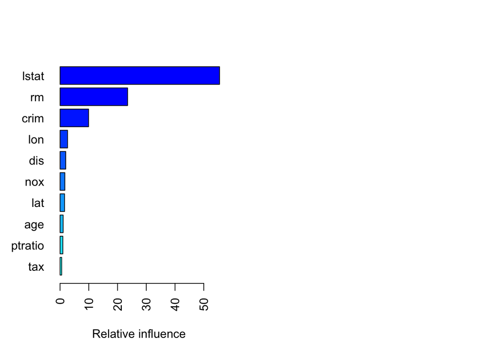

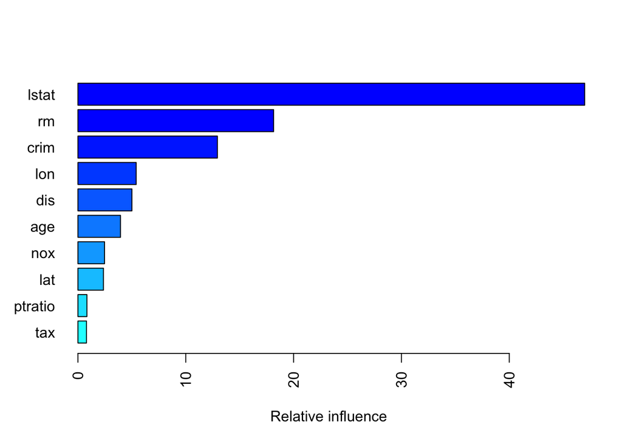

```
##        var    rel.inf
## 1    lstat 46.9921210
## 2       rm 18.1468970
## 3     crim 12.9336936
## 4      lon  5.4035500
## 5      dis  5.0083208
## 6      age  3.9477929
## 7      nox  2.4677146
## 8      lat  2.3663326
## 9  ptratio  0.8346349
## 10     tax  0.7929412
## 11   indus  0.4274400
## 12    chas  0.2313825
## 13     rad  0.2285759
## 14      zn  0.2186029
```

```r
summary(myfit1, cBars = 10,
  method = permutation.test.gbm,
  las = 2)
```